# Lab 9: Working with COVID-19 Reporting Data

Jarrod Daniels

3/25/2020

```r
library(tidyverse)
library(lubridate)
report_03_11_2020 <-   read_csv(url("https://raw.githubusercontent.com/CSSEGISandData/COVID-19/master/csse_covid_19_data/csse_covid_19_daily_reports/03-11-2020.csv")) %>%
  rename(Country.Region = "Country/Region", Province.State = "Province/State")
```

Checking the table properties to make sure the data imported as we expected

```r
head(report_03_11_2020)
```

```
## # A tibble: 6 x 8
##   Province.State Country.Region `Last Update`       Confirmed Deaths Recovered
##   <chr>          <chr>          <dttm>                  <dbl>  <dbl>     <dbl>
## 1 Hubei          China          2020-03-11 10:53:02     67773   3046     49134
## 2 <NA>           Italy          2020-03-11 21:33:02     12462    827      1045
## 3 <NA>           Iran           2020-03-11 18:52:03      9000    354      2959
## 4 <NA>           Korea, South   2020-03-11 21:13:18      7755     60       288
## 5 France         France         2020-03-11 22:53:03      2281     48        12
## 6 <NA>           Spain          2020-03-11 20:53:02      2277     54       183
## # ... with 2 more variables: Latitude <dbl>, Longitude <dbl>
```

```r
str(report_03_11_2020)
```

```
## Classes 'spec_tbl_df', 'tbl_df', 'tbl' and 'data.frame': 216 obs. of  8 variables:
##  $ Province.State: chr  "Hubei" NA NA NA ...
##  $ Country.Region: chr  "China" "Italy" "Iran" "Korea, South" ...
##  $ Last Update   : POSIXct, format: "2020-03-11 10:53:02" "2020-03-11 21:33:02" ...
##  $ Confirmed     : num  67773 12462 9000 7755 2281 ...
##  $ Deaths        : num  3046 827 354 60 48 ...
##  $ Recovered     : num  49134 1045 2959 288 12 ...
##  $ Latitude      : num  31 43 32 36 46.2 ...
##  $ Longitude     : num  112.27 12 53 128 2.21 ...
##  - attr(*, "spec")=
##   .. cols(
##   ..   `Province/State` = col_character(),
##   ..   `Country/Region` = col_character(),
##   ..   `Last Update` = col_datetime(format = ""),
##   ..   Confirmed = col_double(),
##   ..   Deaths = col_double(),
##   ..   Recovered = col_double(),
##   ..   Latitude = col_double(),
##   ..   Longitude = col_double()
##   .. )
```

The data seen above is from older reports and with new reports, the format of the data has changed. The new report is seen below.

```r
report_03_23_2020 <-   read_csv(url("https://raw.githubusercontent.com/CSSEGISandData/COVID-19/master/csse_covid_19_data/csse_covid_19_daily_reports/03-23-2020.csv"))
head(report_03_23_2020)
```

```
## # A tibble: 6 x 12
##   FIPS  Admin2 Province_State Country_Region Last_Update           Lat  Long_
##   <chr> <chr>  <chr>          <chr>          <dttm>              <dbl>  <dbl>
## 1 45001 Abbev~ South Carolina US             2020-03-23 23:19:34  34.2  -82.5
## 2 22001 Acadia Louisiana      US             2020-03-23 23:19:34  30.3  -92.4
## 3 51001 Accom~ Virginia       US             2020-03-23 23:19:34  37.8  -75.6
## 4 16001 Ada    Idaho          US             2020-03-23 23:19:34  43.5 -116.
## 5 19001 Adair  Iowa           US             2020-03-23 23:19:34  41.3  -94.5
## 6 21001 Adair  Kentucky       US             2020-03-23 23:19:34  37.1  -85.3
## # ... with 5 more variables: Confirmed <dbl>, Deaths <dbl>, Recovered <dbl>,
## #   Active <dbl>, Combined_Key <chr>
```

```r
str(report_03_23_2020)
```

```
## Classes 'spec_tbl_df', 'tbl_df', 'tbl' and 'data.frame': 3415 obs. of  12 variables:
##  $ FIPS          : chr  "45001" "22001" "51001" "16001" ...
##  $ Admin2        : chr  "Abbeville" "Acadia" "Accomack" "Ada" ...
##  $ Province_State: chr  "South Carolina" "Louisiana" "Virginia" "Idaho" ...
##  $ Country_Region: chr  "US" "US" "US" "US" ...
##  $ Last_Update   : POSIXct, format: "2020-03-23 23:19:34" "2020-03-23 23:19:34" ...
##  $ Lat           : num  34.2 30.3 37.8 43.5 41.3 ...
##  $ Long_         : num  -82.5 -92.4 -75.6 -116.2 -94.5 ...
##  $ Confirmed     : num  1 1 1 13 1 0 2 0 18 0 ...
##  $ Deaths        : num  0 0 0 0 0 0 0 0 0 0 ...
##  $ Recovered     : num  0 0 0 0 0 0 0 0 0 0 ...
##  $ Active        : num  0 0 0 0 0 0 0 0 0 0 ...
##  $ Combined_Key  : chr  "Abbeville, South Carolina, US" "Acadia, Louisiana, US" "Accomack, Virginia, US" "Ada, Idaho, US" ...
##  - attr(*, "spec")=
##   .. cols(
##   ..   FIPS = col_character(),
##   ..   Admin2 = col_character(),
##   ..   Province_State = col_character(),
##   ..   Country_Region = col_character(),
##   ..   Last_Update = col_datetime(format = ""),
##   ..   Lat = col_double(),
##   ..   Long_ = col_double(),
##   ..   Confirmed = col_double(),
##   ..   Deaths = col_double(),
##   ..   Recovered = col_double(),
##   ..   Active = col_double(),
##   ..   Combined_Key = col_character()
##   .. )
```

Now create a plot of confirmed cases in the US as of March 11th

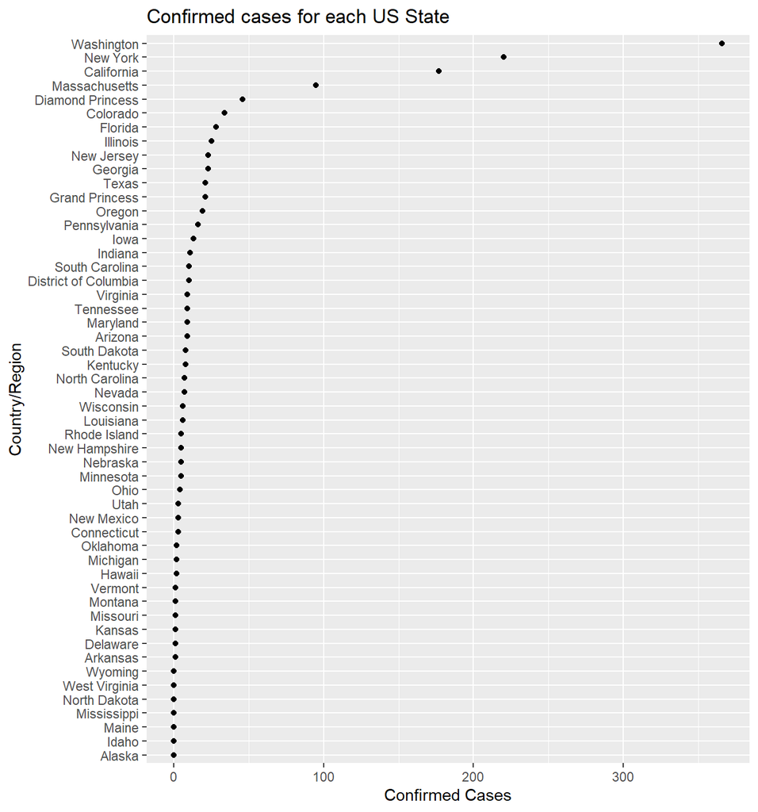

```r
report_03_11_2020 %>%
  filter (Country.Region == "US") %>%
  ggplot(aes(x = Confirmed,  y = reorder(Province.State, Confirmed))) +
    geom_point() +
    ggtitle("Confirmed cases for each US State") +
    ylab("Country/Region") +
    xlab("Confirmed Cases")
```

Now we summarise the data based on the deaths by country

```r
report_03_11_2020 %>%
  group_by(Country.Region) %>%
  summarise(Deaths = sum(Deaths)) %>%
  arrange(desc(Deaths))
```

```
## # A tibble: 116 x 2
##    Country.Region Deaths
##    <chr>           <dbl>
##  1 China            3161
##  2 Italy             827
##  3 Iran              354
##  4 Korea, South       60
##  5 Spain              54
##  6 France             48
##  7 US                 36
##  8 Japan              15
##  9 United Kingdom      8
## 10 Cruise Ship         7
## # ... with 106 more rows
```

Now we can plot the top 20 countries with the most COVID-19 related deaths

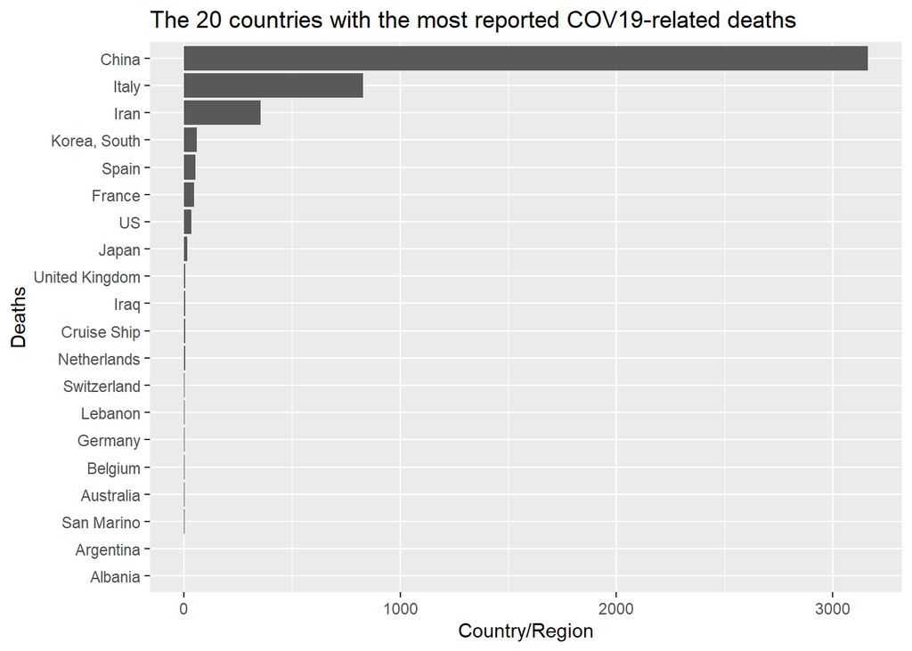

```r
report_03_11_2020 %>%
  group_by(Country.Region) %>%
  summarise(Deaths = sum(Deaths)) %>%
  arrange(desc(Deaths)) %>%
  slice(1:20) %>%
  ggplot(aes(x = reorder(Country.Region, Deaths),  y = Deaths)) +
    geom_bar(stat = 'identity') +
    ggtitle("The 20 countries with the most reported COV19-related deaths") +
    ylab("Country/Region") +
    xlab("Deaths")+
coord_flip()
```

# **Working with the time series data**

```r
time_series_confirmed <- read_csv(url("https://raw.githubusercontent.com/CSSEGISandData/COVID-19/master/csse_covid_19_data/csse_covid_19_time_series/time_series_covid19_confirmed_global.csv")) %>%
  rename(Province_State = "Province/State", Country_Region = "Country/Region")
```

Checking data properties

```r
head(time_series_confirmed)
```

```
## # A tibble: 6 x 73
##   Province_State Country_Region   Lat   Long `1/22/20` `1/23/20` `1/24/20`
##   <chr>          <chr>          <dbl>  <dbl>     <dbl>     <dbl>     <dbl>
## 1 <NA>           Afghanistan     33    65            0         0         0
## 2 <NA>           Albania         41.2  20.2          0         0         0
## 3 <NA>           Algeria         28.0   1.66         0         0         0
## 4 <NA>           Andorra         42.5   1.52         0         0         0
## 5 <NA>           Angola         -11.2  17.9          0         0         0
## 6 <NA>           Antigua and B~  17.1 -61.8          0         0         0
## # ... with 66 more variables: `1/25/20` <dbl>, `1/26/20` <dbl>,
## #   `1/27/20` <dbl>, `1/28/20` <dbl>, `1/29/20` <dbl>, `1/30/20` <dbl>,
## #   `1/31/20` <dbl>, `2/1/20` <dbl>, `2/2/20` <dbl>, `2/3/20` <dbl>,
## #   `2/4/20` <dbl>, `2/5/20` <dbl>, `2/6/20` <dbl>, `2/7/20` <dbl>,
## #   `2/8/20` <dbl>, `2/9/20` <dbl>, `2/10/20` <dbl>, `2/11/20` <dbl>,
## #   `2/12/20` <dbl>, `2/13/20` <dbl>, `2/14/20` <dbl>, `2/15/20` <dbl>,
## #   `2/16/20` <dbl>, `2/17/20` <dbl>, `2/18/20` <dbl>, `2/19/20` <dbl>,
## #   `2/20/20` <dbl>, `2/21/20` <dbl>, `2/22/20` <dbl>, `2/23/20` <dbl>,
## #   `2/24/20` <dbl>, `2/25/20` <dbl>, `2/26/20` <dbl>, `2/27/20` <dbl>,
## #   `2/28/20` <dbl>, `2/29/20` <dbl>, `3/1/20` <dbl>, `3/2/20` <dbl>,
## #   `3/3/20` <dbl>, `3/4/20` <dbl>, `3/5/20` <dbl>, `3/6/20` <dbl>,
## #   `3/7/20` <dbl>, `3/8/20` <dbl>, `3/9/20` <dbl>, `3/10/20` <dbl>,
## #   `3/11/20` <dbl>, `3/12/20` <dbl>, `3/13/20` <dbl>, `3/14/20` <dbl>,
## #   `3/15/20` <dbl>, `3/16/20` <dbl>, `3/17/20` <dbl>, `3/18/20` <dbl>,
## #   `3/19/20` <dbl>, `3/20/20` <dbl>, `3/21/20` <dbl>, `3/22/20` <dbl>,
## #   `3/23/20` <dbl>, `3/24/20` <dbl>, `3/25/20` <dbl>, `3/26/20` <dbl>,
## #   `3/27/20` <dbl>, `3/28/20` <dbl>, `3/29/20` <dbl>, `3/30/20` <dbl>
```

```r
time_series_confirmed_long <- time_series_confirmed %>%
               pivot_longer(-c(Province_State, Country_Region, Lat, Long),
                            names_to = "Date", values_to = "Confirmed")
```

Now we can look at the format of the dataframe

```r
head(time_series_confirmed_long)
```

```
## # A tibble: 6 x 6
##   Province_State Country_Region   Lat  Long Date    Confirmed
##   <chr>          <chr>          <dbl> <dbl> <chr>       <dbl>
## 1 <NA>           Afghanistan       33    65 1/22/20         0
## 2 <NA>           Afghanistan       33    65 1/23/20         0
## 3 <NA>           Afghanistan       33    65 1/24/20         0
## 4 <NA>           Afghanistan       33    65 1/25/20         0
## 5 <NA>           Afghanistan       33    65 1/26/20         0
## 6 <NA>           Afghanistan       33    65 1/27/20         0
```

It is also helpful to get the confirmed deaths in the same table. We can create another table with deaths and join the two tables.

```r
time_series_deaths <- read_csv(url("https://raw.githubusercontent.com/CSSEGISandData/COVID-19/master/csse_covid_19_data/csse_covid_19_time_series/time_series_covid19_deaths_global.csv")) %>%
  rename(Province_State = "Province/State", Country_Region = "Country/Region")
```

Now we convert it to long format

```r
time_series_deaths_long <- time_series_deaths %>%
  pivot_longer(-c(Province_State, Country_Region, Lat, Long),
               names_to = "Date", values_to = "Deaths")
head(time_series_deaths_long)
```

```
## # A tibble: 6 x 6
##   Province_State Country_Region   Lat  Long Date    Deaths
##   <chr>          <chr>          <dbl> <dbl> <chr>    <dbl>
## 1 <NA>           Afghanistan       33    65 1/22/20      0
## 2 <NA>           Afghanistan       33    65 1/23/20      0
## 3 <NA>           Afghanistan       33    65 1/24/20      0
## 4 <NA>           Afghanistan       33    65 1/25/20      0
## 5 <NA>           Afghanistan       33    65 1/26/20      0
## 6 <NA>           Afghanistan       33    65 1/27/20      0
```

To join 2 tables we need a common column in which each row is a unique name. This is often called the Key. None of the columns in this data set meet that criteria, but we can create a column to serve as our key by mergering the names for the Province_State, Country_Region and Date columns using unite.

```r
time_series_confirmed_long <- time_series_confirmed_long %>%
  unite(Key, Province_State, Country_Region, Date, sep = ".", remove = FALSE)
head(time_series_confirmed_long)
```

```
## # A tibble: 6 x 7
##   Key                 Province_State Country_Region   Lat  Long Date   Confirmed
##   <chr>               <chr>          <chr>          <dbl> <dbl> <chr>      <dbl>
## 1 NA.Afghanistan.1/2~ <NA>           Afghanistan       33    65 1/22/~         0
## 2 NA.Afghanistan.1/2~ <NA>           Afghanistan       33    65 1/23/~         0
## 3 NA.Afghanistan.1/2~ <NA>           Afghanistan       33    65 1/24/~         0
## 4 NA.Afghanistan.1/2~ <NA>           Afghanistan       33    65 1/25/~         0
## 5 NA.Afghanistan.1/2~ <NA>           Afghanistan       33    65 1/26/~         0
## 6 NA.Afghanistan.1/2~ <NA>           Afghanistan       33    65 1/27/~         0
```

For the second table we can do the same and eliminate the columns that are redundant so that we just have the Key and Deaths columns

```r
time_series_deaths_long <- time_series_deaths_long %>%
  unite(Key, Province_State, Country_Region, Date, sep = ".") %>%
  select(Key, Deaths)
```

Now to join the tables. A full_join which means that the keys that are common to the tables will be joined and there will be counts for both Confirmed and Deaths. Where there are not matching values, returns NA for the one missing. select can be used to remove the key after the join since we don’t have further need for it.

```r
time_series_long_joined <- full_join(time_series_confirmed_long,
              time_series_deaths_long, by = c("Key"))
head(time_series_long_joined)
```

```
## # A tibble: 6 x 8
##   Key           Province_State Country_Region   Lat  Long Date  Confirmed Deaths
##   <chr>         <chr>          <chr>          <dbl> <dbl> <chr>     <dbl>  <dbl>
## 1 NA.Afghanist~ <NA>           Afghanistan       33    65 1/22~         0      0
## 2 NA.Afghanist~ <NA>           Afghanistan       33    65 1/23~         0      0
## 3 NA.Afghanist~ <NA>           Afghanistan       33    65 1/24~         0      0
## 4 NA.Afghanist~ <NA>           Afghanistan       33    65 1/25~         0      0
## 5 NA.Afghanist~ <NA>           Afghanistan       33    65 1/26~         0      0
## 6 NA.Afghanist~ <NA>           Afghanistan       33    65 1/27~         0      0
```

We can now check to make sure neither the Cofirmed or Death counts have NA as a value (both tables have the same number of rows, but we should check to make sure)

```r
which(is.na(time_series_long_joined$Confirmed))
```

```
## integer(0)
```

```r
which(is.na(time_series_long_joined$Deaths))
```

```
## integer(0)
```

We can now perform the same set of steps to add the recovered data to the table

```r
time_series_recovered <- read_csv(url("https://raw.githubusercontent.com/CSSEGISandData/COVID-19/master/csse_covid_19_data/csse_covid_19_time_series/time_series_covid19_recovered_global.csv")) %>%
  rename(Province_State = "Province/State", Country_Region = "Country/Region")
time_series_recovered_long <- time_series_recovered %>%
  pivot_longer(-c(Province_State, Country_Region, Lat, Long),
               names_to = "Date", values_to = "Recovered")


time_series_recovered_long <- time_series_recovered_long %>%
  unite(Key, Province_State, Country_Region, Date, sep = ".") %>%
  select(Key, Recovered)


time_series_long_joined <- full_join(time_series_long_joined,
              time_series_recovered_long, by = c("Key")) %>%
    select(-Key)
head(time_series_long_joined)
```

```
## # A tibble: 6 x 8
##   Province_State Country_Region   Lat  Long Date    Confirmed Deaths Recovered
##   <chr>          <chr>          <dbl> <dbl> <chr>       <dbl>  <dbl>     <dbl>
## 1 <NA>           Afghanistan       33    65 1/22/20         0      0         0
## 2 <NA>           Afghanistan       33    65 1/23/20         0      0         0
## 3 <NA>           Afghanistan       33    65 1/24/20         0      0         0
## 4 <NA>           Afghanistan       33    65 1/25/20         0      0         0
## 5 <NA>           Afghanistan       33    65 1/26/20         0      0         0
## 6 <NA>           Afghanistan       33    65 1/27/20         0      0         0
```

Before we can begin we must reformat data

```r
time_series_long_joined$Date <- mdy(time_series_long_joined$Date)
```

Confirmed, Deaths and Recovered are all count data, and there may be times when we want to plot all three on the same graph. There are multiple ways to accomplish this and one is through creating a column will all 3 using _pivot_long

```r
time_series_long_joined_counts <- time_series_long_joined %>%
  pivot_longer(-c(Province_State, Country_Region, Lat, Long, Date),
               names_to = "Report_Type", values_to = "Counts")
head(time_series_long_joined_counts)
```

```
## # A tibble: 6 x 7
##   Province_State Country_Region   Lat  Long Date       Report_Type Counts
##   <chr>          <chr>          <dbl> <dbl> <date>     <chr>        <dbl>
## 1 <NA>           Afghanistan       33    65 2020-01-22 Confirmed        0
## 2 <NA>           Afghanistan       33    65 2020-01-22 Deaths           0
## 3 <NA>           Afghanistan       33    65 2020-01-22 Recovered        0
## 4 <NA>           Afghanistan       33    65 2020-01-23 Confirmed        0
## 5 <NA>           Afghanistan       33    65 2020-01-23 Deaths           0
## 6 <NA>           Afghanistan       33    65 2020-01-23 Recovered        0
```

# **Making Graphs from time series data

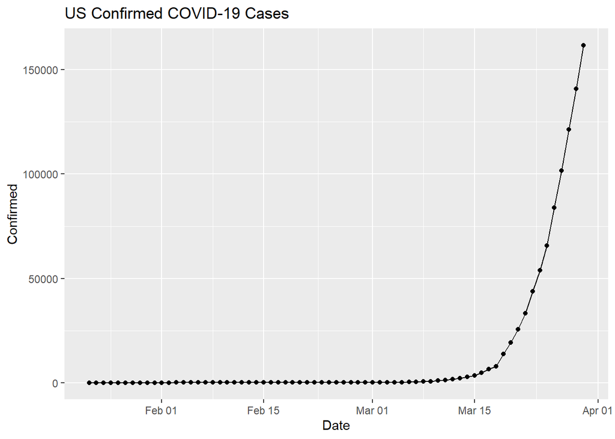

```r
time_series_long_joined %>%
  group_by(Country_Region,Date) %>%
  summarise_at(c("Confirmed", "Deaths", "Recovered"), sum) %>%
  filter (Country_Region == "US") %>%
    ggplot(aes(x = Date,  y = Confirmed)) +
    geom_point() +
    geom_line() +
    ggtitle("US Confirmed COVID-19 Cases")
```

We can also add in multiple countries

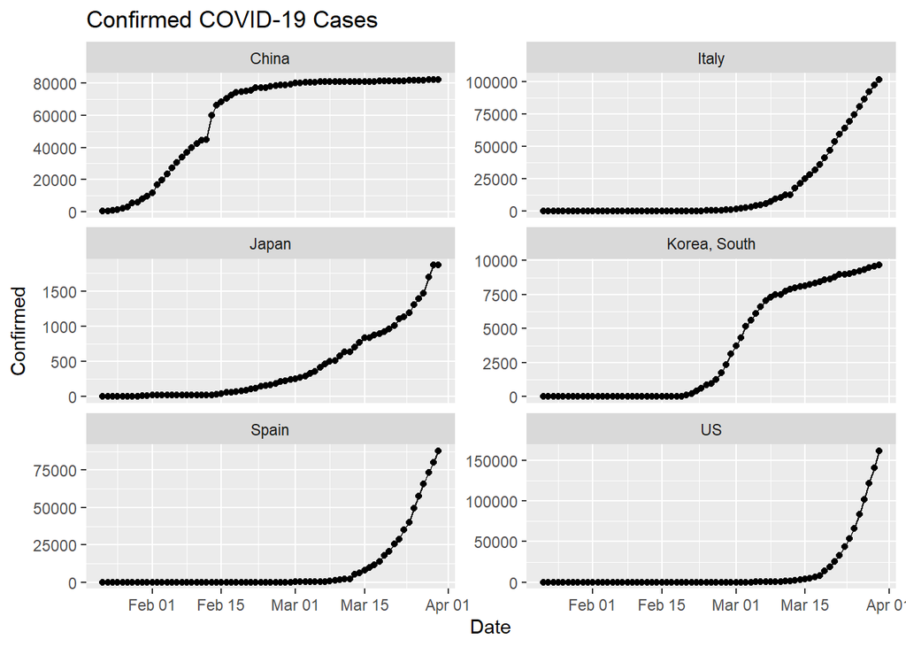

```r
time_series_long_joined %>%
  group_by(Country_Region,Date) %>%
  summarise_at(c("Confirmed", "Deaths", "Recovered"), sum) %>%
  filter (Country_Region %in% c("China","Japan", "Korea, South",
                                "Italy","Spain", "US")) %>%
    ggplot(aes(x = Date,  y = Confirmed)) +
    geom_point() +
    geom_line() +
    ggtitle("Confirmed COVID-19 Cases") +
    facet_wrap(~Country_Region, ncol=2, scales="free_y")
```

We can also put the multiple countries on a single graph

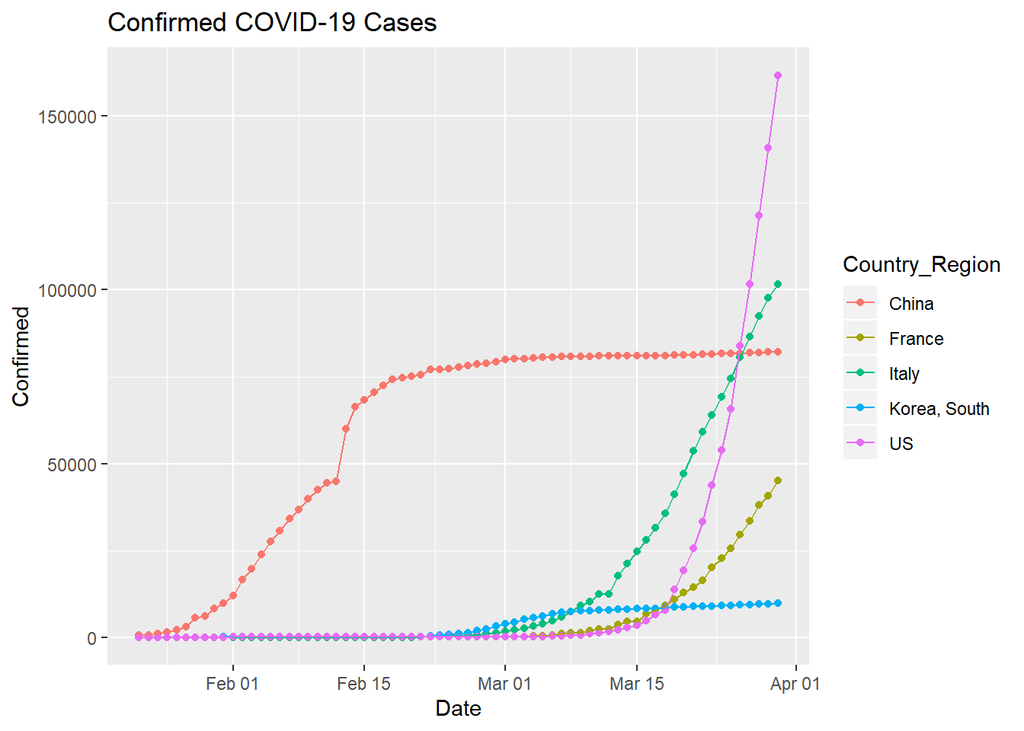

```r
time_series_long_joined %>%
    group_by(Country_Region,Date) %>%
    summarise_at(c("Confirmed", "Deaths", "Recovered"), sum) %>%
    filter (Country_Region %in% c("China","France","Italy",
                                "Korea, South", "US")) %>%
    ggplot(aes(x = Date,  y = Confirmed, color = Country_Region)) +
    geom_point() +
    geom_line() +
    ggtitle("Confirmed COVID-19 Cases")
```

We can use the alternative data frame with column Report_Type to show Confirmed, Deaths and Recovered. Because the counts for Deaths and Recovered are low relative to Confirmed a log scale works best here for seeing the pattern

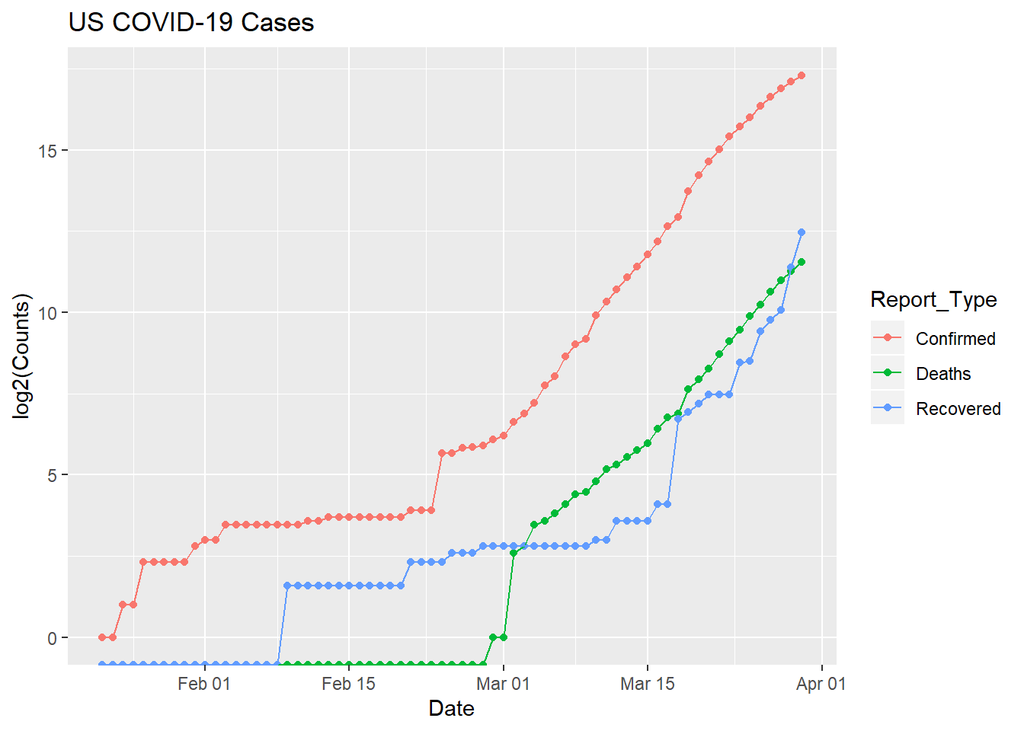

```r
time_series_long_joined_counts %>%
  group_by(Country_Region, Report_Type, Date) %>%
  summarise(Counts = sum(Counts)) %>%
  filter (Country_Region == "US") %>%
    ggplot(aes(x = Date,  y = log2(Counts), fill = Report_Type, color = Report_Type)) +
    geom_point() +
    geom_line() +
    ggtitle("US COVID-19 Cases")
```

# **Visualizing data on maps**

Here are two examples provided by Prof. Chris Sunderland and Anisa Dhana

```r
library(maps)
library(viridis)
```

Get the world map

```r
world <- map_data("world")
```

Cutoffs based on the number of cases

```r
mybreaks <- c(1, 20, 100, 1000, 50000)
```

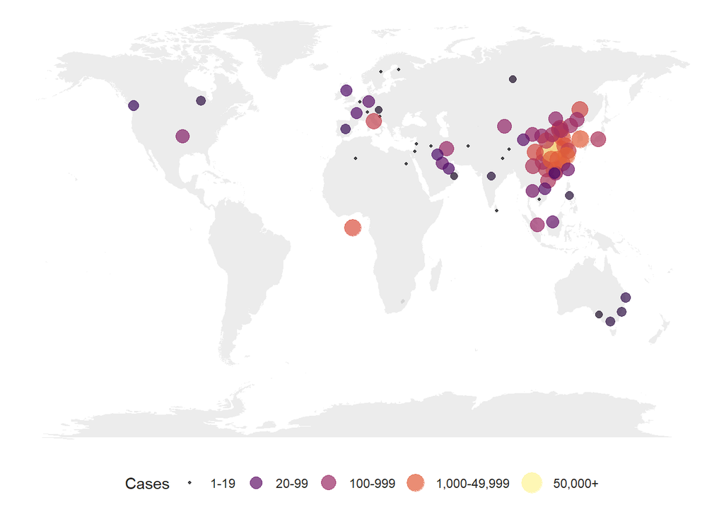

```r
ggplot() +
  geom_polygon(data = world, aes(x=long, y = lat, group = group), fill="grey", alpha=0.3) +
  geom_point(data=time_series_confirmed, aes(x=Long, y=Lat, size=`2/25/20`, color=`2/25/20`),stroke=F, alpha=0.7) +
  scale_size_continuous(name="Cases", trans="log", range=c(1,7),breaks=mybreaks, labels = c("1-19", "20-99", "100-999", "1,000-49,999", "50,000+")) +
  # scale_alpha_continuous(name="Cases", trans="log", range=c(0.1, 0.9),breaks=mybreaks) +
  scale_color_viridis_c(option="inferno",name="Cases", trans="log",breaks=mybreaks, labels = c("1-19", "20-99", "100-999", "1,000-49,999", "50,000+")) +
  theme_void() +
  guides( colour = guide_legend()) +
  labs(caption = "") +
  theme(
    legend.position = "bottom",
    text = element_text(color = "#22211d"),
    plot.background = element_rect(fill = "#ffffff", color = NA),
    panel.background = element_rect(fill = "#ffffff", color = NA),
    legend.background = element_rect(fill = "#ffffff", color = NA)
  )
```

Adaptation of code from Prof. Chris Sunderland Get data, pivot to longer format and summarize

```r
time_series_confirmed_long2 <- read_csv(url("https://raw.githubusercontent.com/CSSEGISandData/COVID-19/master/csse_covid_19_data/csse_covid_19_time_series/time_series_covid19_confirmed_global.csv")) %>%
    rename(Province.State = "Province/State", Country.Region = "Country/Region") %>%
    pivot_longer(-c(Province.State, Country.Region, Lat, Long),
    names_to = "Date", values_to = "cumulative_cases") %>%
    mutate(Date = mdy(Date) - days(1),
        Place = paste(Lat,Long,sep="_")) %>%
    group_by(Place,Date) %>%
        summarise(cumulative_cases = ifelse(sum(cumulative_cases)>0,
        sum(cumulative_cases),NA_real_),
        Lat = mean(Lat),
        Long = mean(Long)) %>%
    mutate(Pandemic_day = as.numeric(Date - min(Date)))
```

View the table

```r
head(time_series_confirmed_long2)
```

```
## # A tibble: 6 x 6
## # Groups:   Place [1]
##   Place           Date       cumulative_cases     Lat  Long Pandemic_day
##   <chr>           <date>                <dbl>   <dbl> <dbl>        <dbl>
## 1 -0.0236_37.9062 2020-01-21               NA -0.0236  37.9            0
## 2 -0.0236_37.9062 2020-01-22               NA -0.0236  37.9            1
## 3 -0.0236_37.9062 2020-01-23               NA -0.0236  37.9            2
## 4 -0.0236_37.9062 2020-01-24               NA -0.0236  37.9            3
## 5 -0.0236_37.9062 2020-01-25               NA -0.0236  37.9            4
## 6 -0.0236_37.9062 2020-01-26               NA -0.0236  37.9            5
```

Plotting the data

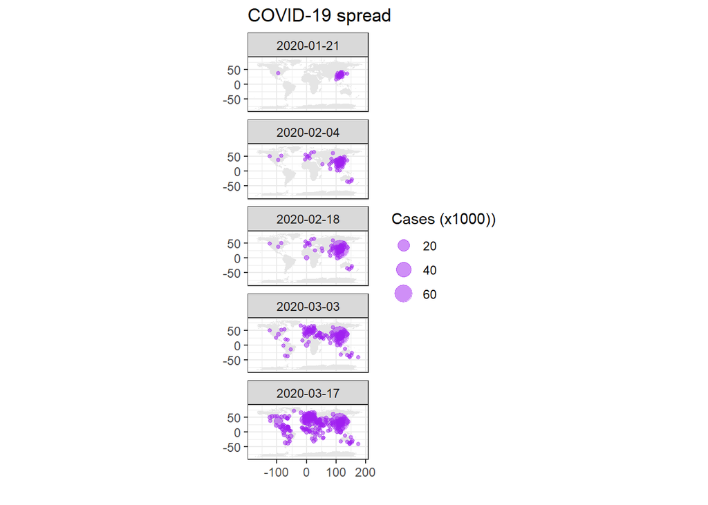

```r
static <- ggplot(subset(time_series_confirmed_long2,Date %in% seq(min(Date),max(Date),14)),
            aes(x = Long, y = Lat, size = cumulative_cases/1000)) +
            borders("world", colour = NA, fill = "grey90") +
            theme_bw() +
            geom_point(shape = 21, color='purple', fill='purple', alpha = 0.5) +
            labs(title = 'COVID-19 spread',x = '', y = '',
                 size="Cases (x1000))") +
            theme(legend.position = "right") +
            coord_fixed(ratio=1)+
            facet_wrap(.~Date,ncol=1)
static
```

Exercises

Report Graphs:

For the first graph I chose to look at the single day stats of Massachusetts in terms of report confirmed, deathly, and recovered cases of COVID-19 in MA. While not the most complicated graph, a simple visualization such as the one below allows you to see distribution of case types for a given day. This also provides the viewer with an opportunity to get a visual idea of how the State of MA is doing in a single moment in time.

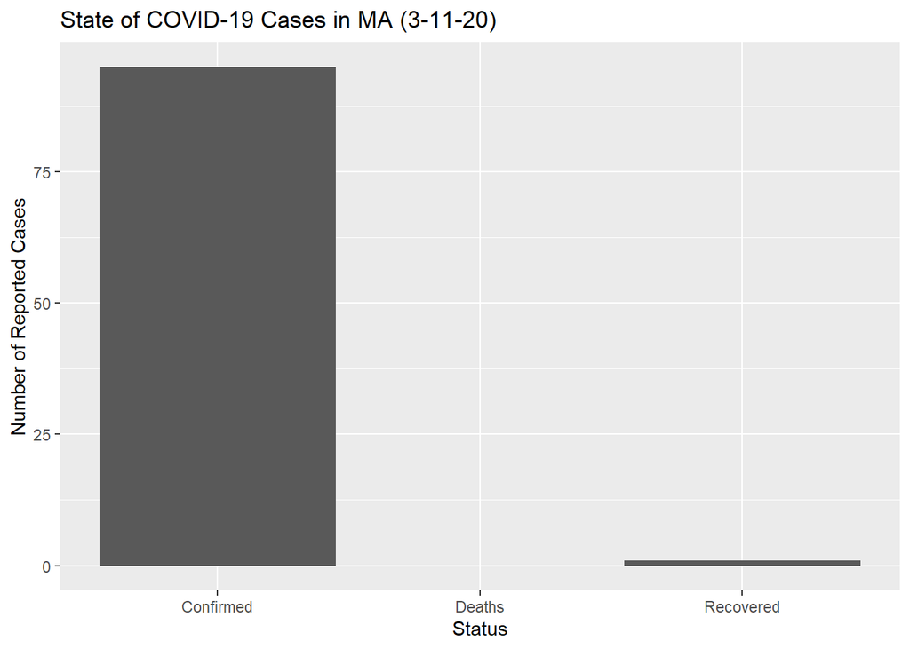

```r
tempData = subset(report_03_11_2020, Province.State=="Massachusetts")
values = rep(c(tempData$Confirmed, tempData$Deaths, tempData$Recovered))
condition = c("Confirmed", "Deaths", "Recovered")
tempData2 = data.frame(condition, values)
ggplot(tempData2, aes(x=condition, y=values)) + geom_bar(stat = 'identity') + ylab("Number of Reported Cases") + xlab("Status") + ggtitle("State of COVID-19 Cases in MA (3-11-20)")
```

Moving on from this, I next wanted to look at what the distribution of COVID-19 cases was for each county in MA. While also simple, this type of visualization allows citizens/viewers to get an idea across the state of which areas have been hit hard by the virus and which have not. This type of visualization is also helpful for possibly identifying epicenters and where the virus outbreak began/where it is heading.

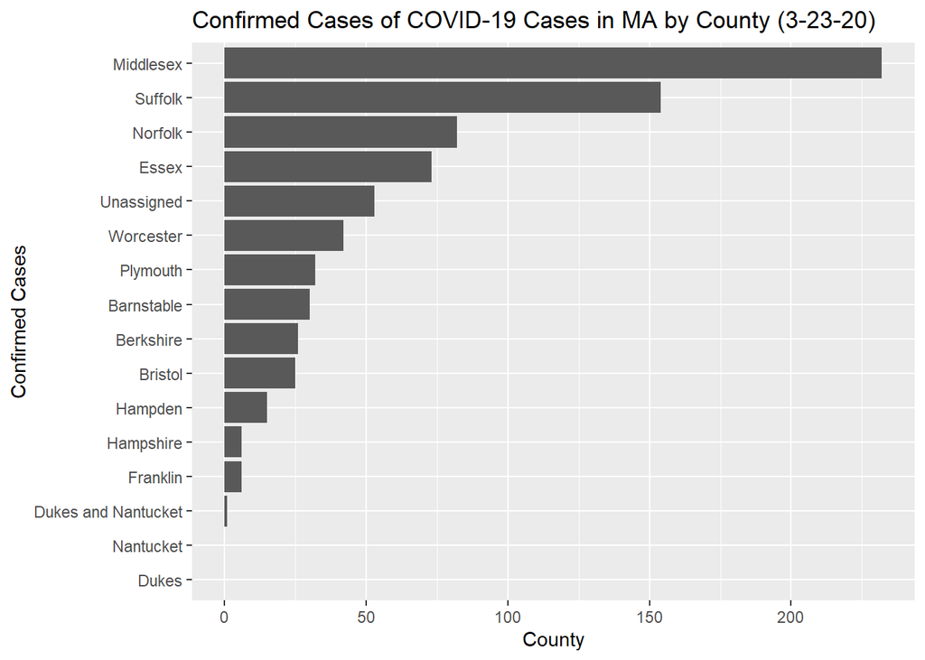

```r
report_03_23_2020 %>%
  filter (Country_Region == "US") %>%
  filter ((Province_State == "Massachusetts")) %>%
  group_by(Admin2) %>%
  ggplot(aes(x = reorder(Admin2, Confirmed),  y = Confirmed)) +
    geom_bar(stat = 'identity') +
    ggtitle("Confirmed Cases of COVID-19 Cases in MA by County (3-23-20)") +
    ylab("County") +
    xlab("Confirmed Cases")+
    coord_flip()
```

Time Series Graphs:

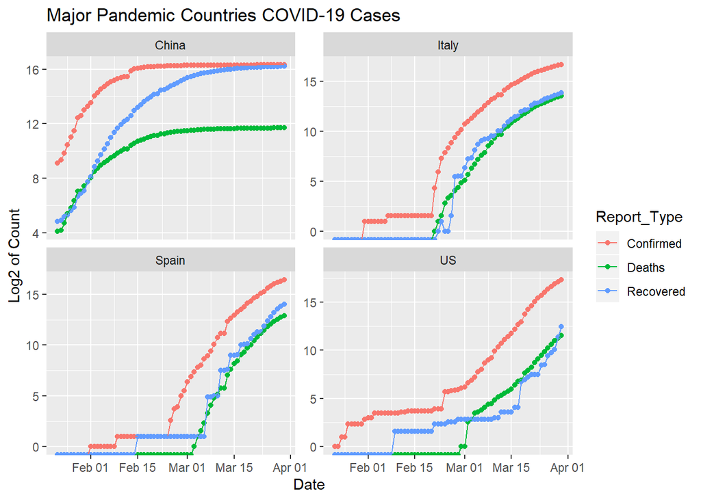

```r
time_series_long_joined_counts %>%
  group_by(Country_Region, Report_Type, Date) %>%
  summarise(Counts = sum(Counts)) %>%
  filter (Country_Region %in% c("US","China", "Italy", "Spain")) %>%
    ggplot(aes(x = Date,  y = log2(Counts), fill = Report_Type, color = Report_Type)) +
    geom_point() +
    geom_line() +
    ylab("Log2 of Count") +
    ggtitle("Major Pandemic Countries COVID-19 Cases") +
    facet_wrap(~Country_Region, ncol=2, scales="free_y")
```

Moving on, much like in the previous section, we can look at data within a single country now and try to identify trends in the data on a more local scale. For this example I decided to look at the provinces in china to see if there was anything interesting to be found. It is also intersting to note that when looking at the data, although the numbers tend to vary greatly (some pronvices hit much harder than others), many provinces share similar trends in the curve for COVID-19 Cases.

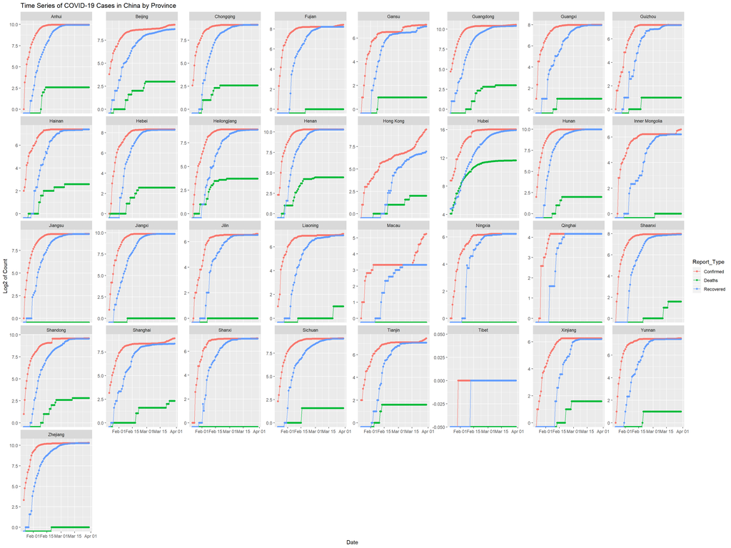

```r
time_series_long_joined_counts %>%
  group_by(Country_Region, Province_State, Report_Type, Date) %>%
  summarise(Counts = sum(Counts)) %>%
  filter (Country_Region == "China") %>%
    ggplot(aes(x = Date,  y = log2(Counts), fill = Report_Type, color = Report_Type)) +
    geom_point() +
    geom_line() +
    ylab("Log2 of Count") +
    ggtitle("Time Series of COVID-19 Cases in China by Province") +
    facet_wrap(~Province_State, ncol=8, scales="free_y")
```

Map Graphs:

Finally, moving onto to map graphs, I wanted to look at the toll that COVID-19 has taken on the world as well as some of the countries with the highest amount of confirmed cases. These visualizations are good for looking at how the virus progresses as time goes on and how each country dealt with it. You could also use this data to find epicenters and area’s of high risk (much like we can do with confirmed cases). The first graph seen below is a single day map of the total confirmed deaths due to covid-19 on a global scale

```r
time_series_death <- read_csv(url("https://raw.githubusercontent.com/CSSEGISandData/COVID-19/master/csse_covid_19_data/csse_covid_19_time_series/time_series_covid19_deaths_global.csv"))
```

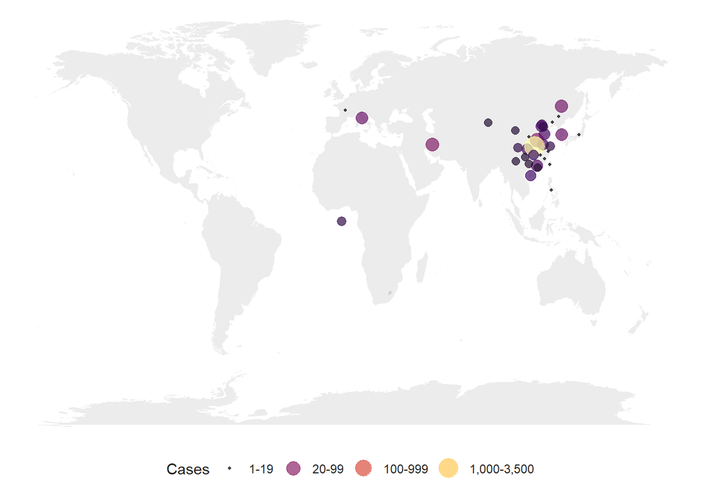

```r
ggplot() +
  geom_polygon(data = world, aes(x=long, y = lat, group = group), fill="grey", alpha=0.3) +
  geom_point(data=time_series_death, aes(x=Long, y=Lat, size=`2/25/20`, color=`2/25/20`),stroke=F, alpha=0.7) +
  scale_size_continuous(name="Cases", trans="log", range=c(1,7),breaks=mybreaks, labels = c("1-19", "20-99", "100-999", "1,000-3,500", "4,000+")) +
  # scale_alpha_continuous(name="Cases", trans="log", range=c(0.1, 0.9),breaks=mybreaks) +
  scale_color_viridis_c(option="inferno",name="Cases", trans="log",breaks=mybreaks, labels = c("1-19", "20-99", "100-999", "1,000-3,500", "4,000+")) +
  theme_void() +
  guides( colour = guide_legend()) +
  labs(caption = "") +
  theme(
    legend.position = "bottom",
    text = element_text(color = "#22211d"),
    plot.background = element_rect(fill = "#ffffff", color = NA),
    panel.background = element_rect(fill = "#ffffff", color = NA),
    legend.background = element_rect(fill = "#ffffff", color = NA)
  )
```

Next I wanted to look at the deaths caused by Corona virus over time. This graph is useful because it allows us to see the speed in which the virus has affected a given country. Specifically when looking at Italy, they quickly surpassed China even though the virus had been in the country for a much shorter period of time. This could be useful for healtcare purposes in identifying areas that were affected by the virus the hardest.

```r
time_series_death_long <- read_csv(url("https://raw.githubusercontent.com/CSSEGISandData/COVID-19/master/csse_covid_19_data/csse_covid_19_time_series/time_series_covid19_deaths_global.csv")) %>%
    rename(Province.State = "Province/State", Country.Region = "Country/Region") %>%
    filter(Country.Region == "Italy" | Country.Region == "China" | Country.Region == "US") %>%
    pivot_longer(-c(Province.State, Country.Region, Lat, Long),
    names_to = "Date", values_to = "cumulative_cases") %>%
    mutate(Date = mdy(Date) - days(1),
        Place = paste(Lat,Long,sep="_")) %>%
    group_by(Place,Date) %>%
        summarise(cumulative_cases = ifelse(sum(cumulative_cases)>0,
        sum(cumulative_cases),NA_real_),
        Lat = mean(Lat),
        Long = mean(Long)) %>%
    mutate(Pandemic_day = as.numeric(Date - min(Date)))
```

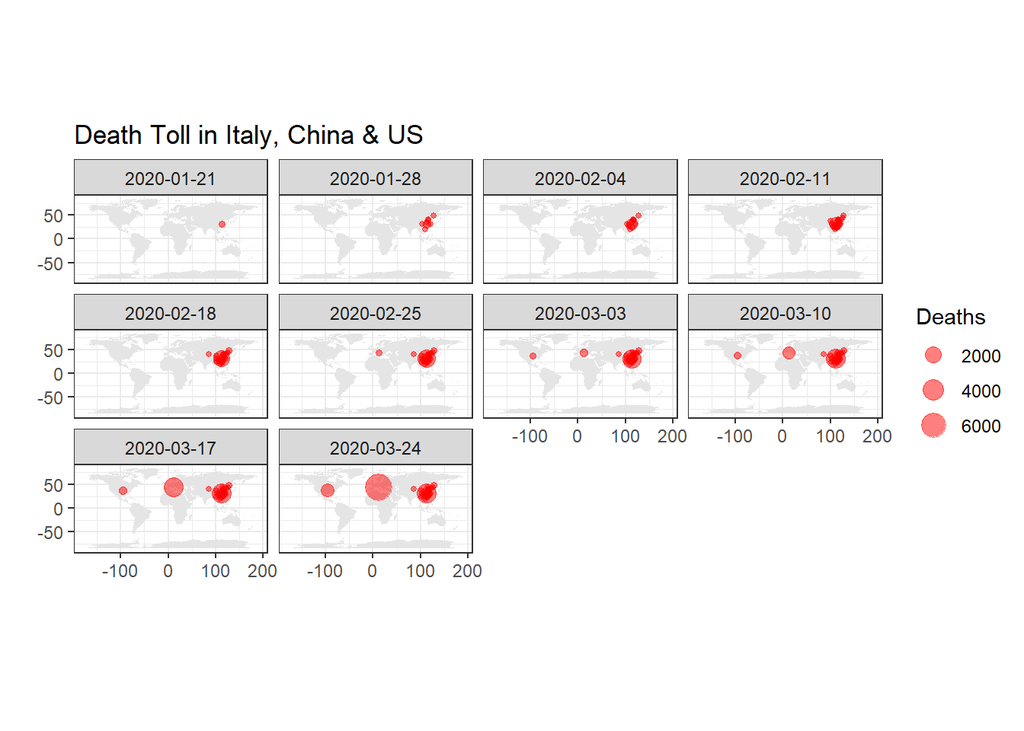

```r
static2 <- ggplot(subset(time_series_death_long,Date %in% seq(min(Date),max(Date),7)),
            aes(x = Long, y = Lat, size = cumulative_cases)) +
            borders("world", colour = NA, fill = "grey90") +
            theme_bw() +
            geom_point(shape = 21, color='red', fill='red', alpha = 0.5) +
            labs(title = 'Death Toll in Italy, China & US',x = '', y = '',
                 size="Deaths") +
            theme(legend.position = "right") +
            coord_fixed(ratio=1)+
            facet_wrap(.~Date,nrow=3)

static2
```

[output not shown]